**Author :** Nicolas Jumel  
**Master REHAB – University of Montpellier**  
**Date :** 2025/2026

# 1 Chronodel presentation

The objectives were to evaluate the Chronodel test, describe the distribution of results, and compare its performance with two other tests assessing similar cognitive functions: *DOTWB* and *MOTYB*.

Initially, sensitivity, specificity, positive predictive value, and negative predictive value were planned for the Chronodel test. However, due to a low variability in the results — with most participants scoring 1 (indicating success) — this analysis was not appropriate.

Therefore, the analysis plan was revised to focus on: - the percentage of success for each test (*DOTWB*, *MOTYB*, *Chronodel*) - the concordance between tests - the distribution of results to assess variability and potential ceiling effects

A small number of missing values were observed. As these were limited and not overlapping across variables, analyses were conducted using available data.

# 2 Data inclusion

Data cleaning was performed prior to analysis using Visual Studio Code. The dataset was then imported into RStudio for statistical analysis.

```r
Data <- read.csv("Stat_Chronodel_Rstudio_test.csv")
```

# 3 Total subjects

**Cohen’s kappa analyses** were conducted using complete cases for each pairwise comparison.. Therefore, the number of complete observations available for jour_reussite (*DOTWB*) and mois_reussi (*MOTYB*) was assessed prior to analysis.

```r
sum(complete.cases(Data[, c("jour_reussite", "mois_reussi")]))
```

```
## [1] 36
```

```r
sum(complete.cases(Data[, c("jour_reussite", "chrono_reussi")]))
```

```
## [1] 37
```

```r
sum(complete.cases(Data[, c("mois_reussi", "chrono_reussi")]))
```

```
## [1] 39
```

## 3.1 Subjects

- *DOTWB* vs *MOTYB* → n = 36
- *DOTWB* vs *Chronodel* → n = 37
- *MOTYB* vs *Chronodel* → n = 39

**Cohen’s kappa analyses** were conducted separately for each pairwise comparison using the corresponding complete-case dataset. The number of available observations varied across comparisons due to missing data patterns.

# 4 Kappa test

```r
library(irr)
kappa2(Data[, c("jour_reussite", "mois_reussi")])
```

```
##  Cohen's Kappa for 2 Raters (Weights: unweighted)
##
##  Subjects = 36
##    Raters = 2
##     Kappa = 0.0859
##
##         z = 1.27
##   p-value = 0.204
```

```r
kappa2(Data[, c("jour_reussite", "chrono_reussi")])
```

```
##  Cohen's Kappa for 2 Raters (Weights: unweighted)
##
##  Subjects = 37
##    Raters = 2
##     Kappa = 0
##
##         z = 0
##   p-value = 1
```

```r
kappa2(Data[, c("mois_reussi", "chrono_reussi")])
```

```
##  Cohen's Kappa for 2 Raters (Weights: unweighted)
##
##  Subjects = 39
##    Raters = 2
##     Kappa = 0
##
##         z = 0
##   p-value = 1
```

## 4.1 Kappa test results

- *DOTWB* vs *MOTYB* : κ = 0.086 (p = 0.204)
- *DOTWB* vs *Chronodel* : κ = 0 (p = 1)
- *MOTYB* vs *Chronodel* : κ = 0 (p = 1)

The **Cohen’s kappa coefficients** indicated a **very low level** of agreement across the three outcome measures. Agreement between *DOTWB* and *MOTYB* was weak (**κ = 0.086**, **p = 0.204**), whereas no agreement beyond chance was observed between *DOTWB* and *Chronodel* (**κ = 0**, **p = 1**), as well as between *MOTYB* and *Chronodel* (**κ = 0**, **p = 1**).

Overall, these results **suggest** a lack of meaningful concordance between the tested variables.

This pattern may be partly explained by **distributional characteristics** of the data, **potentially indicating a ceiling effect**, which will be further explored in the subsequent descriptive analyses and graphical representations.

# 5 Cross table

A cross-tabulation was performed to assess agreement between *DOTWB* and *MOTYB*.(see Table 5.1)

Table 5.1: Cross-tabulation between DOTWB and MOTYB results

|  | 0 | 1 |
| --- | --- | --- |
| 0 | 1 | 0 |
| 1 | 13 | 22 |

## 5.1 *DOTWB* vs *MOTYB* Concordance

- 1 subject failed both *DOTWB* and *MOTYB*
- 0 subjects failed *DOTWB* but succeeded *MOTYB*
- 13 subjects succeeded *DOTWB* but failed *MOTYB*
- 22 subjects succeeded in both tests

This corresponds to a **concordance rate of 63.9 %** (23/36) and a **discordance rate of 36.1 %** (13/36). The relatively high proportion of discordant classifications explains the low Kappa value.

# 6 success rate

The success rates of the three tests were analysed to assess their coherence and potential ceiling effects (see Figure 6.1).

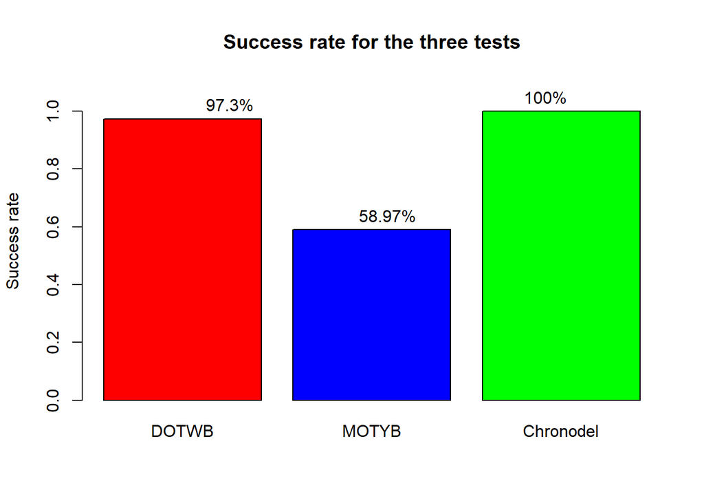

Figure 6.1: Success rates for the three tests

```r
taux_jour <- mean(Data$jour_reussite, na.rm = TRUE)
taux_mois <- mean(Data$mois_reussi, na.rm = TRUE)
taux_chrono <- mean(Data$chrono_reussi, na.rm = TRUE)

taux <- c(taux_jour, taux_mois, taux_chrono)

barplot(taux,
        names.arg = c("DOTWB", "MOTYB", "Chronodel"),
        ylim = c(0,1.1),
        ylab = "Success rate",
        main = "Success rate for the three tests",
        col = c("red", "blue", "green"))

text(x=1, y=taux_jour+0.05, labels=paste0(round(taux_jour*100, 2), "%"))
text(x=2, y=taux_mois+0.05, labels=paste0(round(taux_mois*100, 2), "%"))
text(x=3, y=taux_chrono+0.05, labels=paste0(round(taux_chrono*100, 2), "%"))
```

Overall, success rates were **97.3%** for the *DOTWB* test, **58.97%** for the *MOTYB* test, and **100%** for the *Chronodel test*. A ceiling effect is suggested for the *DOTWB* and *Chronodel test* due to their high success rates, while the *MOTYB* test shows a **more balanced distribution** without evidence of a ceiling effect.

# 7 Distribution

The final figure presents the distribution of results across the three tests, in order to assess **variability** and potential **ceiling effects**.(see Figure 7.1)).

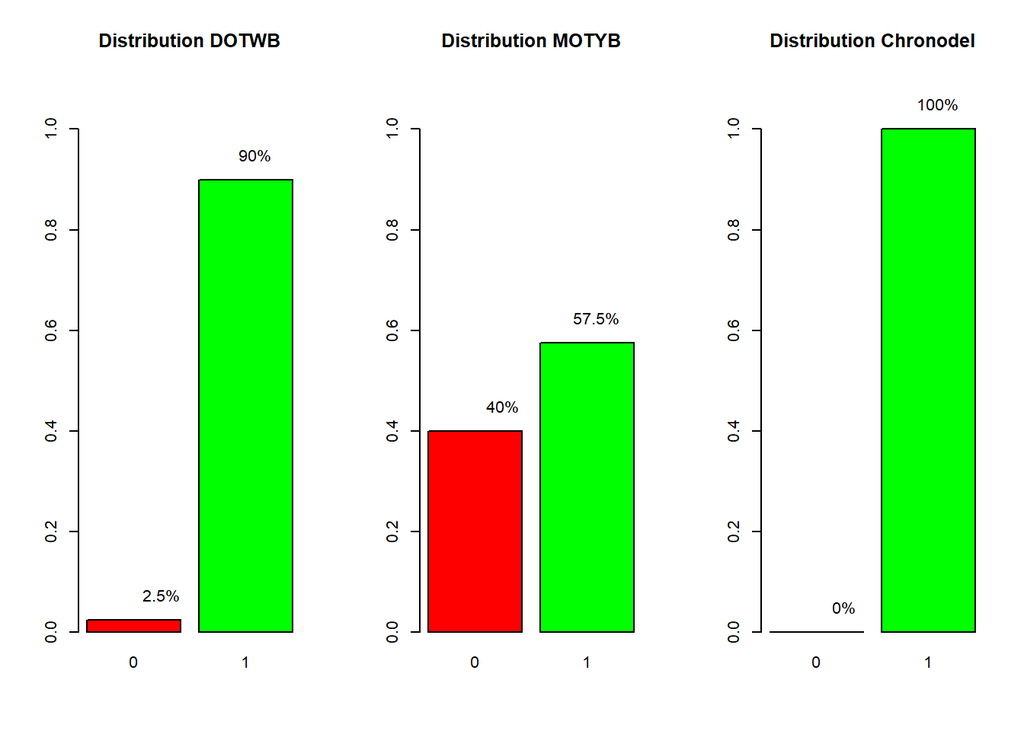

Figure 7.1: Distribution results for the three tests

```r
par(mfrow=c(1,3))


dotwb_tab <- table(factor(Data$jour_reussite, levels = c(0,1))) / nrow(Data)

barplot(dotwb_tab,
        main="Distribution DOTWB",
        ylim=c(0,1.1),
        col=c("red", "green"),
        names.arg=c("0","1"))

text(x=1, y=dotwb_tab[1] + 0.05,
     labels=paste0(round(dotwb_tab[1]*100, 2), "%"))

text(x=2, y=dotwb_tab[2] + 0.05,
     labels=paste0(round(dotwb_tab[2]*100, 2), "%"))


motyb_tab <- table(factor(Data$mois_reussi, levels = c(0,1))) / nrow(Data)

barplot(motyb_tab,
        main="Distribution MOTYB",
        ylim=c(0,1.1),
        col=c("red", "green"),
        names.arg=c("0","1"))

text(x=1, y=motyb_tab[1] + 0.05,
     labels=paste0(round(motyb_tab[1]*100, 2), "%"))

text(x=2, y=motyb_tab[2] + 0.05,
     labels=paste0(round(motyb_tab[2]*100, 2), "%"))


chrono_tab <- table(factor(Data$chrono_reussi, levels = c(0,1))) / nrow(Data)

barplot(chrono_tab,
        main="Distribution Chronodel",
        ylim=c(0,1.1),
        col=c("red", "green"),
        names.arg=c("0","1"))

text(x=1, y=chrono_tab[1] + 0.05,
     labels=paste0(round(chrono_tab[1]*100, 2), "%"))

text(x=2, y=chrono_tab[2] + 0.05,
     labels=paste0(round(chrono_tab[2]*100, 2), "%"))
```

```r
par(mfrow=c(1,1))
```

The distribution of the **DOTWB** test results is highly skewed, with a majority of successful outcomes, **suggesting** a ceiling effect.

The **MOTYB** test shows a more balanced distribution, with 40% “no” and 57.5% “yes”, which **does not suggest a ceiling effect**.

For the **Chronodel test**, all participants achieved a successful outcome, **strongly indicating a ceiling effect**.

# 8 Main results

- The *DOTWB* suggests a possible ceiling effect.
- The *MOTYB* shows no evidence of a ceiling effect.
- The *Chronodel* test demonstrates a clear ceiling effect.

**This interpretation is descriptive and based on outcome distributions rather than on a formal statistical test of ceiling effects.**